# 📘 Análise Comparativa de PM₂.₅ — CAMS x DON nos Municípios do Pará

Lucas Sabino

02/12/2025

# 1 🧩 Introdução

A qualidade do ar é um tema central nas discussões sobre saúde pública e sustentabilidade ambiental. Entre os diversos poluentes atmosféricos, o material particulado fino (PM₂.₅) — partículas com diâmetro inferior a 2,5 micrômetros — é um dos mais críticos, devido à sua capacidade de penetrar profundamente no sistema respiratório humano e causar diversos agravos à saúde, como doenças respiratórias e cardiovasculares.

Neste estudo, foram analisados dados de concentração de PM2.5 referentes a municípios do estado do Pará, uma região caracterizada por intensa atividade agropecuária, ocorrência de queimadas sazonais e variabilidade climática marcante, fatores que influenciam diretamente a qualidade do ar.

O objetivo principal deste estudo é comparar as estimativas de concentração de PM₂.₅ obtidas a partir de duas fontes de dados distintas:

- CAMS (Copernicus Atmosphere Monitoring Service), que fornece estimativas modeladas com base em observações satelitais e assimilação de dados atmosféricos globais; e
- DON, sigla utilizada neste trabalho para representar a base Donkelar, que reúne dados observacionais consolidados de medições locais de qualidade do ar.

A análise visa avaliar o grau de concordância entre as fontes, identificar padrões sazonais e testar estatisticamente se, em média, as estimativas do CAMS diferem de forma significativa dos valores observacionais reportados pela base Donkelar (DON).

# 2 ⚙️ Metodologia

## 2.1 Fontes de Dados e Processamento

Fluxo de trabalho metodológico

[output not shown]

## 2.2 Abordagem Analítica

1. Harmonização dos dados: Padronização de variáveis e unidades entre as fontes
2. Transformação logarítmica: Aplicação de log₁ₚ(PM₂.₅) = log(PM₂.₅ + 1) para reduzir assimetria
3. Análise exploratória:
- Mapas de distribuição espacial
- Boxplots mensais comparativos
- Séries temporais de diferenças
4. Análise estatística: Testes de hipótese para diferenças sistemáticas

# 3 📊 Resultados e Discussão

## 3.1 Distribuição Espacial das Concentrações Médias

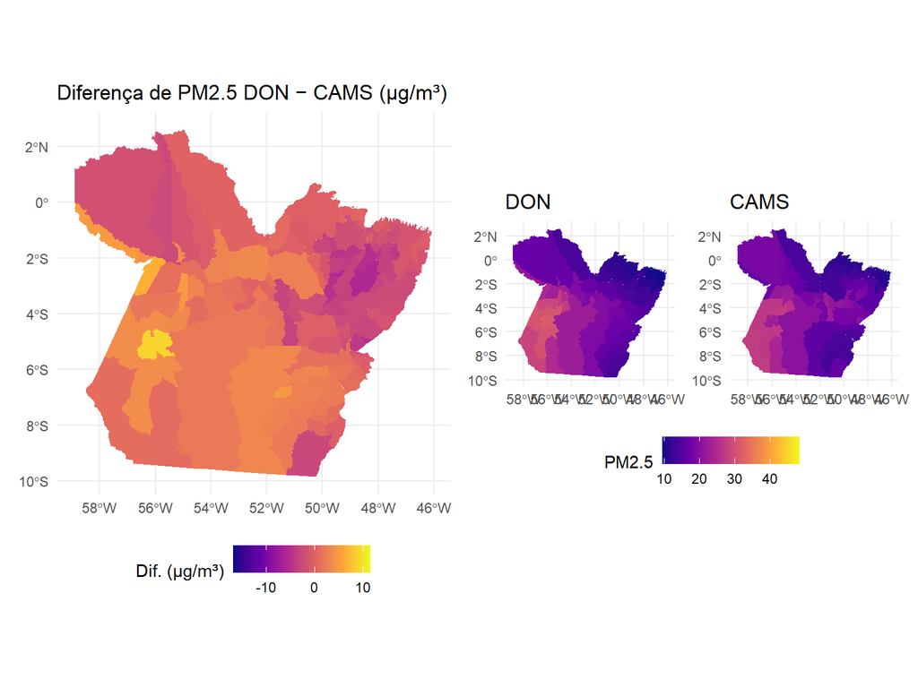

No mapa de diferenças, **a maior parte dos municípios apresenta valores próximos de zero**, indicando consistência entre as estimativas. Contudo, **áreas amareladas** revelam locais onde o **DON estimou concentrações mais altas que o CAMS**, com destaque para o **município de Trairão (PA)**, que apresenta a **diferença positiva mais acentuada**. Essa discrepância pode refletir **condições locais de emissão** ou **diferenças na resolução espacial** dos modelos utilizados.

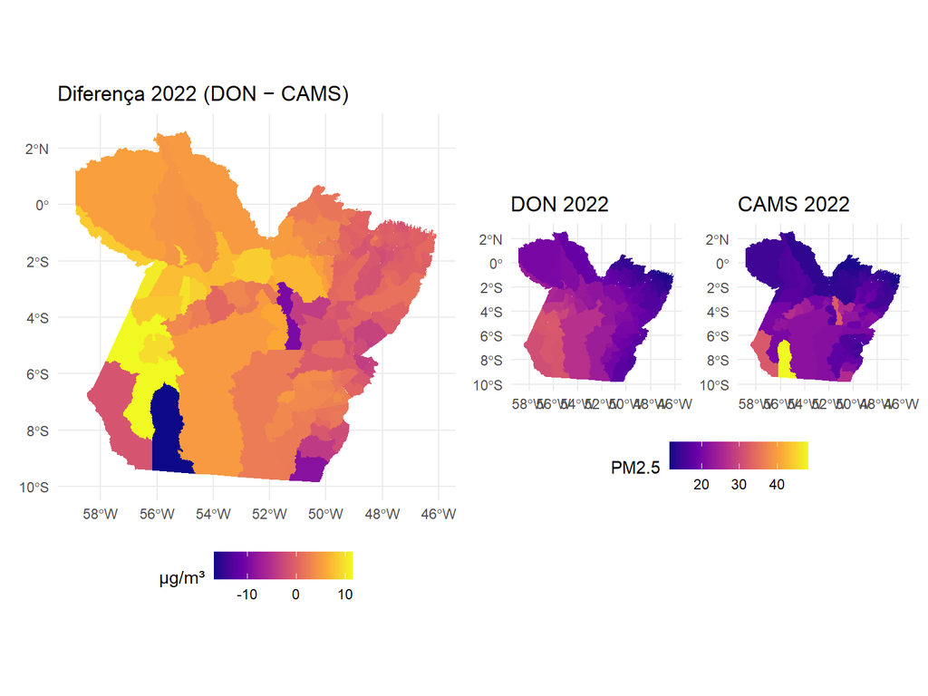

O mapa apresenta as diferenças anuais de concentração média de PM2.5 (µg/m³) entre as fontes **DON (Donkelar)** e **CAMS (Copernicus)** no ano de 2022. De modo geral, observa-se **boa correspondência espacial entre as duas estimativas**, embora existam discrepâncias pontuais em algumas áreas do sudoeste do Pará.

Os tons **amarelados** indicam locais onde o **DON estimou concentrações mais altas** que o CAMS, enquanto os **tons azulados** representam o inverso. Destacam-se dois municípios: **Itaituba**, que apresenta uma **diferença positiva expressiva** (DON > CAMS), sugerindo estimativas mais elevadas de PM2.5 pela base Donkelar; e **Novo Progresso**, onde ocorre o oposto — uma **diferença negativa** (DON < CAMS), indicando valores maiores no CAMS.

Essas variações locais podem estar associadas a **condições específicas de emissão**, intensidade de queimadas ou diferenças na **resolução espacial e nos métodos de interpolação** entre as fontes. Apesar dessas divergências pontuais, o padrão geral reforça a **coerência global entre DON e CAMS** na representação da distribuição espacial de PM₂.₅ para o ano de 2022.

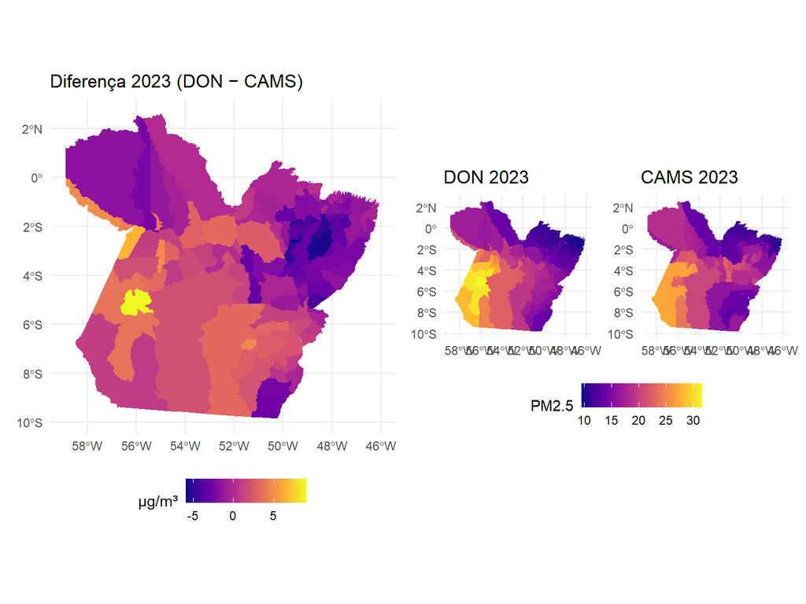

O mapa apresenta as diferenças médias anuais de PM₂.₅ (µg/m³) entre as bases **DON (Donkelar)** e **CAMS (Copernicus)** para o ano de 2023. Em termos gerais, observa-se **boa correspondência entre as duas fontes**, com a maior parte dos municípios apresentando diferenças próximas de zero.

No restante do território, as diferenças se mantêm sutis, reforçando a **consistência geral entre os conjuntos de dados** e a estabilidade do padrão espacial observado em relação ao ano anterior (2022).

## 3.2 Análise das distribuições mensais — Boxplots

Com o objetivo de comparar as concentrações mensais de PM2.5 estimadas pelas fontes DON (Donkelar) e CAMS (Copernicus), foram elaborados boxplots representando a distribuição dos valores ao longo de cada mês e ano analisado. Essa abordagem permite observar a variação intra e interanual dos dados, bem como possíveis diferenças sistemáticas entre as duas fontes.

Inicialmente, o boxplot foi construído utilizando os valores originais de PM2.5 (µg/m³). No entanto, verificou-se a presença de um grande número de outliers, o que dificultou a visualização dos padrões centrais e a comparação entre os meses. Esses valores extremos refletem a alta variabilidade espacial das concentrações, especialmente em regiões com ocorrência pontual de queimadas intensas.

Para contornar essa limitação, foi aplicado um ajuste logarítmico às observações, por meio da transformação log(x + 1). Essa transformação reduziu a amplitude dos valores, diminuindo a influência dos outliers e permitindo uma visualização mais equilibrada das distribuições mensais. Com isso, tornou-se possível identificar com maior clareza as tendências de variação entre meses e entre fontes, preservando a estrutura relativa dos dados.

### 3.2.1 Visao Geral

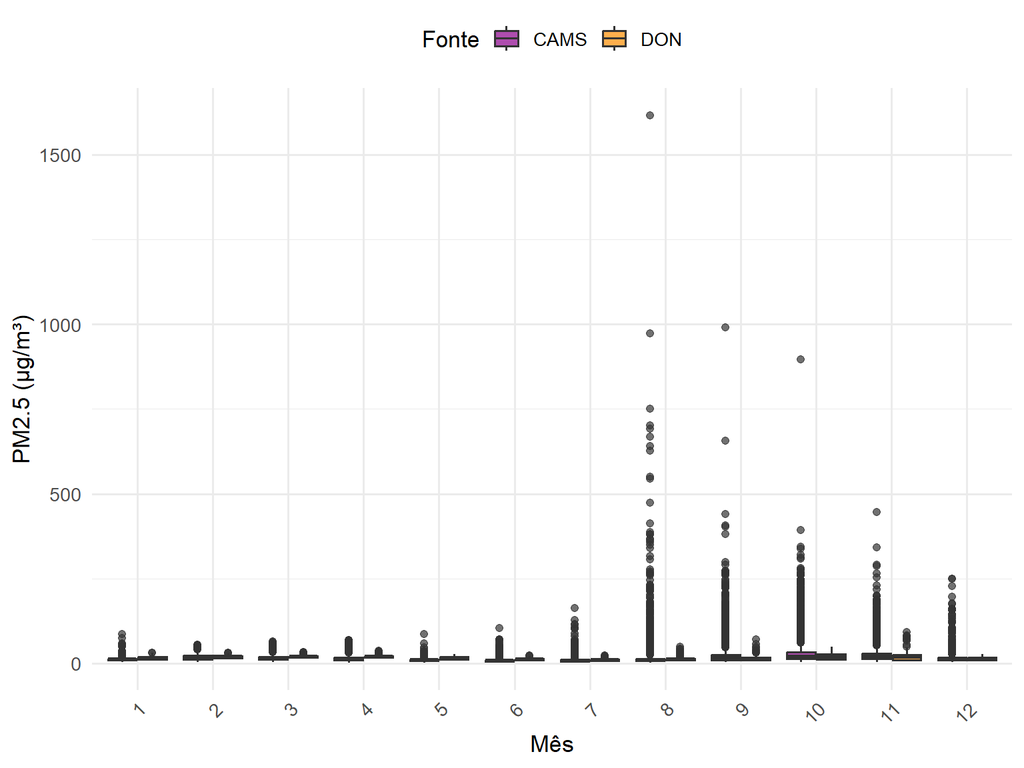

Para comparar as concentrações mensais de PM₂.₅ das fontes CAMS e DON, utilizou-se a representação por boxplots. Inicialmente, a análise com os dados originais foi prejudicada pela alta frequência de outliers, resultantes da variabilidade espacial inerente aos dados, particularmente de eventos pontuais como queimadas. Para contornar esse obstáculo e permitir uma visualização mais clara dos padrões de distribuição, optou-se por aplicar uma transformação logarítmica na forma de log(PM2.5 + 1) aos dados.

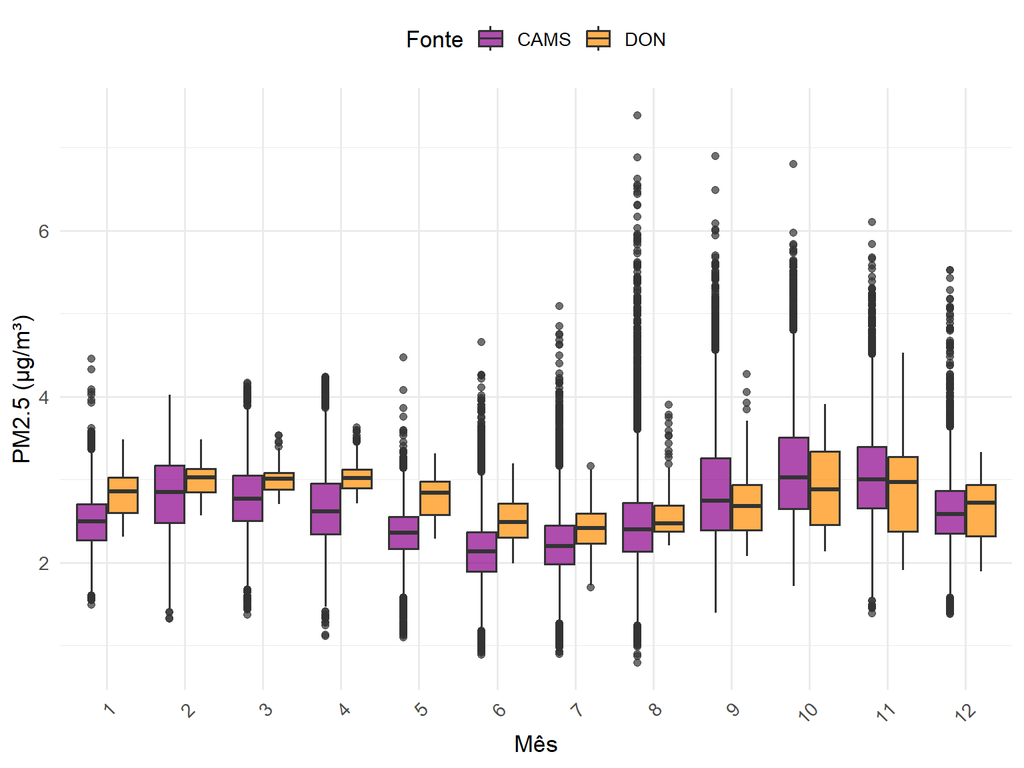

### 3.2.2 Visao Anual

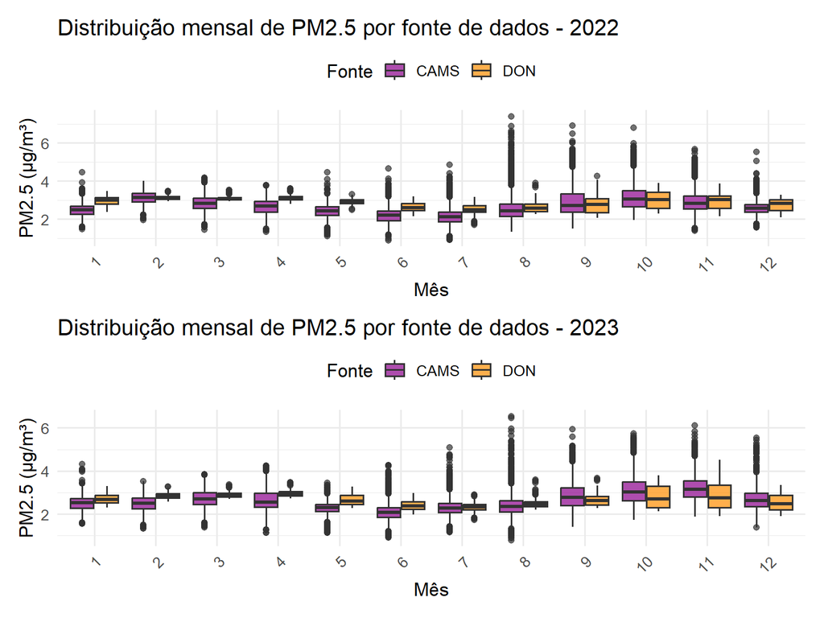

# 4 📈 Análise de Correlação e Concordância

## 4.1 🔹 Cálculo das correlações

Coeficientes de Correlação entre CAMS e DON

| Método | Correlação | Interpretação |
| --- | --- | --- |
| Pearson | 0.754 | Correlação moderada |
| Spearman | 0.786 | Correlação moderada |

Correlação de Pearson (r = 0,75): indica uma associação linear moderada a forte entre as duas bases. Em geral, quando os valores do CAMS aumentam, os valores do DON também aumentam. Isso sugere que as duas fontes captam de forma semelhante as variações espaciais e/ou temporais da concentração de PM₂.₅.

Correlação de Spearman (ρ = 0,79): mede a correlação por postos (ordem dos valores). Como é um pouco maior, mostra que, mesmo que a relação não seja perfeitamente linear, a ordem dos municípios/anos com maiores e menores concentrações é consistente entre as duas bases.

## 4.2 🔹 Gráfico de Dispersão

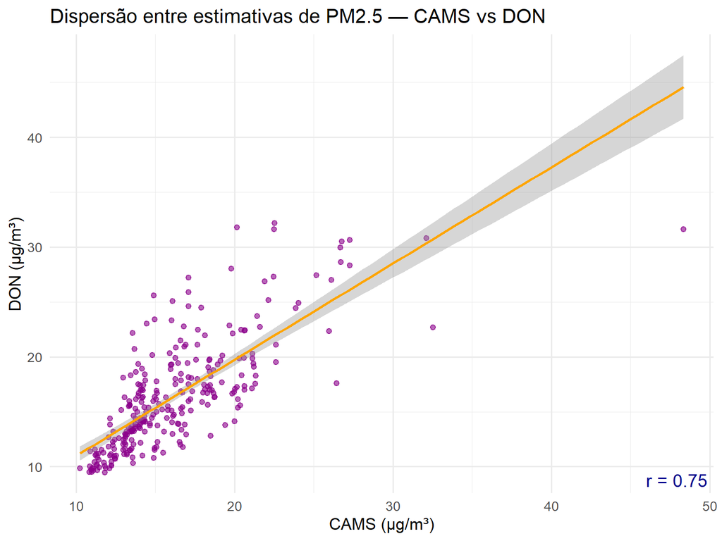

O ajuste linear (linha laranja) mostra uma tendência positiva clara: os pontos estão próximos da linha, embora com alguma dispersão, principalmente em níveis mais altos de PM₂.₅.

A nuvem de pontos é concentrada entre 10 e 25 µg/m³, o que é coerente com os valores típicos observados na região.

O coeficiente mostrado no canto (“r = 0.75”) reforça visualmente essa correlação moderada.

## 4.3 🔹 Gráfico de Bland–Altman

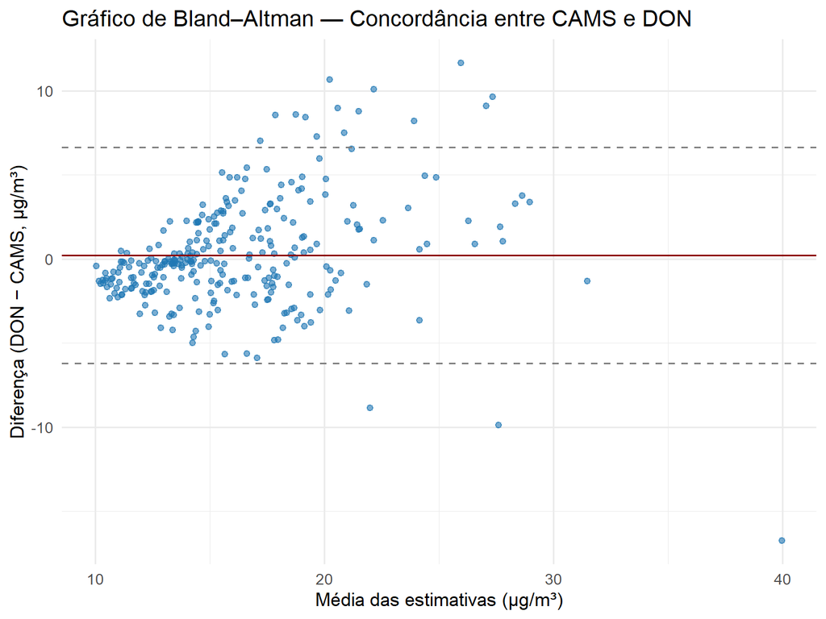

O gráfico de Bland–Altman indica boa concordância entre CAMS e DON, com viés médio próximo de zero e diferenças dentro de limites aceitáveis para a maioria dos municípios. Pequenas divergências em níveis mais altos de PM₂.₅ sugerem que as fontes mantêm consistência geral, mas podem divergir sob condições extremas de concentração atmosférica.

##🔹 Medida de Concordância (Lin’s CCC)

Coeficiente de Concordância de Lin (CCC) entre CAMS e DON

| Estatística | Valor | Interpretação |
| --- | --- | --- |
| Concordance Correlation Coefficient (Lin’s CCC) | 0.745 | Concordância moderada |
| Limite inferior 95% | 0.691 |  |
| Limite superior 95% | 0.791 |  |

As estimativas de PM₂.₅ obtidas pelas bases CAMS e DON são estatisticamente consistentes e comparáveis, captando de maneira semelhante a variação espacial dos níveis de poluição, com diferenças residuais aceitáveis para aplicações regionais ou modelagem ambiental.

## 4.4 Séries Temporais das Diferenças Anuais

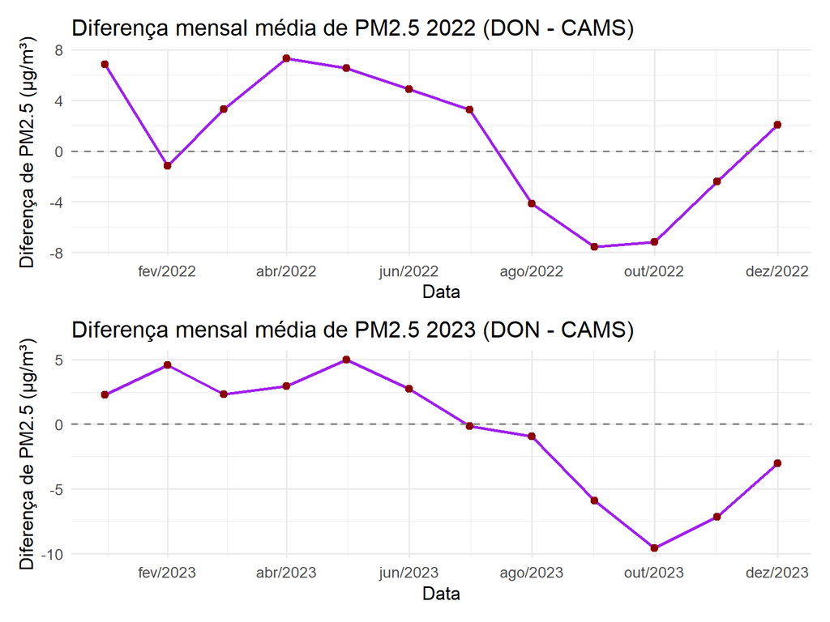

As séries temporais das diferenças entre CAMS e DON evidenciam um padrão sazonal bem definido, com alternância entre superestimação e subestimação ao longo do ano. A magnitude das diferenças permanece dentro de um intervalo moderado, indicando boa estabilidade temporal e coerência entre as fontes, embora a influência de processos sazonais — como queimadas e condições meteorológicas — ainda introduza variação sistemática nas estimativas mensais.

## 4.5 Testes de Hipóteses

Para verificar estatisticamente as diferenças observadas nas séries temporais, foram realizados testes de hipótese t para ambas as bases de dados. Os testes avaliaram a hipótese nula (H₀) de que a média das diferenças entre DON e CAMS é igual a zero, contra a hipótese alternativa (H₁) de que as médias são diferentes. Os resultados obtidos foram:

Resultados dos Testes de Hipótese t para Diferenças DON - CAMS

| Ano | Estatística t | Valor-p | Média das Diferenças (µg/m³) | IC 95% Inferior | IC 95% Superior | Significância | Interpretação |
| --- | --- | --- | --- | --- | --- | --- | --- |
| 2022 | 0.63650 | 0.5375 | 0.98 | -2.41 | 4.38 | Não significativa | Não há evidências de diferença sistemática entre DON e CAMS |
| 2023 | -0.41611 | 0.6853 | -0.58 | -3.65 | 2.49 | Não significativa | Não há evidências de diferença sistemática entre DON e CAMS |

# 5 🧠 Conclusão

Os resultados obtidos apontam para uma boa concordância geral entre as fontes CAMS e DON na estimativa de concentrações de PM₂.₅ nos municípios de Pará, embora existam variações mensais relevantes que merecem atenção. A metodologia empregada — baseada na integração de dados, comparação gráfica e análise estatística — demonstrou ser eficaz para avaliar a coerência entre diferentes fontes de monitoramento atmosférico.

Considerando a importância ambiental e sanitária da poluição por material particulado na região, este estudo reforça a utilidade de bases globais de reanálise, como o CAMS, para complementar e validar medições locais em estados de grande extensão territorial e baixa densidade de monitoramento, como é o caso de Pará.

Trabalhos futuros podem explorar a modelagem temporal (como modelos ARIMA ou regressões sazonais) e análises espaciais mais detalhadas, de modo a compreender melhor as causas das discrepâncias observadas e apoiar políticas públicas de controle da poluição atmosférica na região.

## 5.1 Tabela Resumo

Resumo Executivo das Médias Mensais por Fonte de Dados

[output not shown]